# Tipologia i cicle de vida de les dades

### 4.1.1 Resultats

```r
table_res<-matrix(c(round(mean(dataset_final$Price_Per_Person),2),
         round(mean(dataset_final$Age_imp),2),
         round(mean(dataset_final.Viu$Price_Per_Person),2),
         round(mean(dataset_final.Mor$Price_Per_Person),2),
         round(mean(dataset_final.Class1$Price_Per_Person),2),
         round(mean(dataset_final.Class2$Price_Per_Person),2),
         round(mean(dataset_final.Class3$Price_Per_Person),2),
         round(mean(dataset_final.Viu$Age_imp),2),
         round(mean(dataset_final.Mor$Age_imp),2),
         round(median(dataset_final$Price_Per_Person),2),
         round(median(dataset_final$Age_imp),2),
         round(median(dataset_final.Viu$Price_Per_Person),2),
         round(median(dataset_final.Mor$Price_Per_Person),2),
         round(median(dataset_final.Class1$Price_Per_Person),2),
         round(median(dataset_final.Class2$Price_Per_Person),2),
         round(median(dataset_final.Class3$Price_Per_Person),2),
         round(median(dataset_final.Viu$Age_imp),2),
         round(median(dataset_final.Mor$Age_imp),2),
         round(sd(dataset_final$Price_Per_Person),2),
         round(sd(dataset_final$Age_imp),2),
         round(sd(dataset_final.Viu$Price_Per_Person),2),
         round(sd(dataset_final.Mor$Price_Per_Person),2),
         round(sd(dataset_final.Class1$Price_Per_Person),2),
         round(sd(dataset_final.Class2$Price_Per_Person),2),
         round(sd(dataset_final.Class3$Price_Per_Person),2),
         round(sd(dataset_final.Viu$Age_imp),2),
         round(sd(dataset_final.Mor$Age_imp),2),
         shapiro.Price[2],
         shapiro.Age_imp[2],
         shapiro.Su.Price[2],
         shapiro.Mo.Price[2],
         shapiro.C1.Price[2],
         shapiro.C2.Price[2],
         shapiro.C3.Price[2],
         shapiro.Su.Age_imp[2],
         shapiro.Mo.Age_imp[2]),ncol=4)


colnames(table_res)<-c("Mean","Median","sd","Shapiro-Wilk (p)")
rownames(table_res)<-c("Price","Age","Price Supervivents","Price Morts","Price Class 1", "Price Class 2", "Price Class 3", "Age Supervivents","Age Morts")
table_res<-as.table(table_res)
```

Resultats de les distribucions de les variables contínues’.

|  | Mean | Median | sd | Shapiro-Wilk (p) |
| --- | --- | --- | --- | --- |
| Price | 20.51 | 8.57 | 35.76 | 9.25115055575609e-54 |
| Age | 29.15 | 26 | 13.36 | 1.72081984344405e-16 |
| Price Supervivents | 13.65 | 7.92 | 18.92 | 4.67584912263855e-38 |
| Price Morts | 29.97 | 13 | 51.12 | 6.8562878170371e-31 |
| Price Class 1 | 54.17 | 33.3 | 59.32 | 1.44437662905357e-27 |
| Price Class 2 | 13.35 | 13 | 9.29 | 6.52564417492086e-27 |
| Price Class 3 | 7.97 | 7.75 | 5.85 | 3.0972660079262e-44 |
| Age Supervivents | 29.7 | 26 | 13.02 | 2.09657419131529e-12 |
| Age Morts | 28.08 | 27 | 14.13 | 0.00040288352431829 |

Podem observar com cap de les variables continues analitzades (Age i Price) segueix una distribució normal en cap dels grups testats. El p-value del test de Shapiro-Wilk és < 0.5 en tots els casos. Per tant, en tots els casos és rebutja la hipòtesis nul·la que considera que la distribució és normal.

Comprobem si la variable edat segueix una distribució normal en algun dels grups creats anteriorment.

```r
shapiro.C1.Age_imp<-shapiro.test(dataset_final.Class1$Age_imp)
shapiro.C2.Age_imp<-shapiro.test(dataset_final.Class2$Age_imp)
shapiro.C3.Age_imp<-shapiro.test(dataset_final.Class3$Age_imp)
shapiro.Male.Age_imp<-shapiro.test(dataset_final.Male$Age_imp)
shapiro.Female.Age_imp<-shapiro.test(dataset_final.Female$Age_imp)
shapiro.ZA.Age_imp<-shapiro.test(dataset_final.ZA$Age_imp)
shapiro.ZB.Age_imp<-shapiro.test(dataset_final.ZB$Age_imp)
shapiro.ZC.Age_imp<-shapiro.test(dataset_final.ZC$Age_imp)
shapiro.ZD.Age_imp<-shapiro.test(dataset_final.ZD$Age_imp)
shapiro.ZE.Age_imp<-shapiro.test(dataset_final.ZE$Age_imp)
shapiro.ZF.Age_imp<-shapiro.test(dataset_final.ZF$Age_imp)
shapiro.ZG.Age_imp<-shapiro.test(dataset_final.ZG$Age_imp)
shapiro.sol.Age_imp<-shapiro.test(dataset_final.sol$Age_imp)
shapiro.petita.Age_imp<-shapiro.test(dataset_final.petita$Age_imp)
shapiro.moderada.Age_imp<-shapiro.test(dataset_final.moderada$Age_imp)
shapiro.gran.Age_imp<-shapiro.test(dataset_final.gran$Age_imp)
shapiro.baix.Age_imp<-shapiro.test(dataset_final.baix$Age_imp)
shapiro.mig.Age_imp<-shapiro.test(dataset_final.mig$Age_imp)
shapiro.alt.Age_imp<-shapiro.test(dataset_final.alt$Age_imp)
shapiro.Master.Age_imp<-shapiro.test(dataset_final.Master$Age_imp)
shapiro.Miss.Age_imp<-shapiro.test(dataset_final.Miss$Age_imp)
shapiro.Mr.Age_imp<-shapiro.test(dataset_final.Mr$Age_imp)
shapiro.Mrs.Age_imp<-shapiro.test(dataset_final.Mrs$Age_imp)
shapiro.Noble.Age_imp<-shapiro.test(dataset_final.Noble$Age_imp)
```

```r
table_res2<-matrix(c(
  shapiro.C1.Age_imp[2],
  shapiro.C2.Age_imp[2],
  shapiro.C3.Age_imp[2],
  shapiro.Male.Age_imp[2],
  shapiro.Female.Age_imp[2],
  shapiro.ZA.Age_imp[2],
  shapiro.ZB.Age_imp[2],
  shapiro.ZC.Age_imp[2],
  shapiro.ZD.Age_imp[2],
  shapiro.ZE.Age_imp[2],
  shapiro.ZF.Age_imp[2],
  shapiro.ZG.Age_imp[2],
  shapiro.sol.Age_imp[2],
  shapiro.petita.Age_imp[2],
  shapiro.moderada.Age_imp[2],
  shapiro.gran.Age_imp[2],
  shapiro.baix.Age_imp[2],
  shapiro.mig.Age_imp[2],
  shapiro.alt.Age_imp[2],
  shapiro.Master.Age_imp[2],
  shapiro.Miss.Age_imp[2],
  shapiro.Mr.Age_imp[2],
  shapiro.Mrs.Age_imp[2],
  shapiro.Noble.Age_imp[2]),ncol=1)


colnames(table_res2)<-c("Shapiro-Wilk (p)")
rownames(table_res2)<-c("Classe 1","Classe 2","Classe 3","Homes","Dones", "Zona A", "Zona B", "Zona C", "Zona D", "Zona E", "Zona F", "Zona G", "Sol", "Familia petita","Familia moderada", "Familia gran", "Preu tiquet baix", "Preu tiquet mig", "Preu tiquet alt", "Master", "Miss", "Mr", "Mrs", "Nobles")
table_res2<-as.table(table_res2)
```

Test de normalitat en la distribució de l’edat en cadascun dels grups analitzats’.

|  | Shapiro-Wilk (p) |
| --- | --- |
| Classe 1 | 0.556802698329019 |
| Classe 2 | 2.0994911307761e-05 |
| Classe 3 | 8.55408618829332e-16 |
| Homes | 9.46702812199743e-15 |
| Dones | 1.31453223361498e-08 |
| Zona A | 0.172755572131398 |
| Zona B | 0.0287315641925644 |
| Zona C | 0.769303386274288 |
| Zona D | 0.0900579929543195 |
| Zona E | 0.655288626331217 |
| Zona F | 0.162609827978336 |
| Zona G | 0.0764034110542593 |
| Sol | 5.76945371795426e-23 |
| Familia petita | 4.94059521491037e-05 |
| Familia moderada | 0.000165898968996538 |
| Familia gran | 3.29775478487587e-05 |
| Preu tiquet baix | 4.8180779286244e-14 |
| Preu tiquet mig | 7.16765009917152e-07 |
| Preu tiquet alt | 0.143929241502201 |
| Master | 0.000134152501775469 |
| Miss | 3.18629199703566e-07 |
| Mr | 1.82032086961577e-21 |
| Mrs | 4.98766199680562e-05 |
| Nobles | 0.147634611487388 |

Podem observar com hi ha alguns grups on si que l’edat segeuix una distribució normal. Aquest és el cas per exemple dels passatgers de 1a classe, els que van pagar un preu alt per el tiquet (que és bastant equivalent a ser de 1a classe) i segons les zones de la cabina (amb l’excepció de la zona B).

Podem comprobar alguna d’aquestes distribucions de forma visual. Ho farem amb els passatgers que viatgen en class 1.

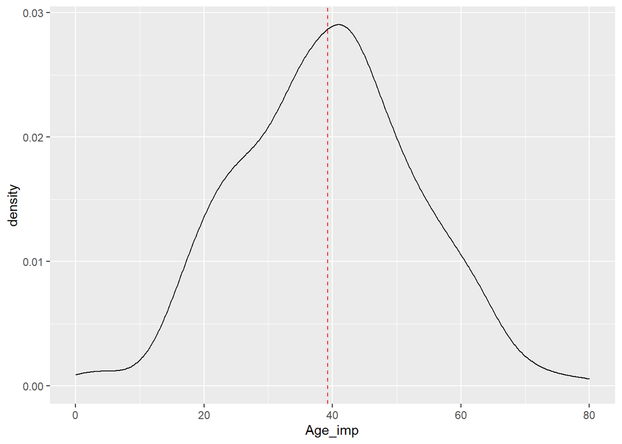

```r
# Use semi-transparent fill
p_AgeClass1<-ggplot(dataset_final.Class1, aes(x=Age_imp)) +
  geom_density(alpha=0.4)+ geom_vline(xintercept = mean(dataset_final.Class1$Age_imp), linetype="dashed",
                color = "red", size=0.5)

p_AgeClass1
```

## 4.2 Comprovació de l’homoscedasticitat

Per a comprobar l’homoscedasticitat (i.e. la homogeneitat de la variança) apliquem el test de Fligner-Killen (test no parametric) ja que com hem vist abans cap de les nostres variables continues segueix una distribució normal.

Aplicarem aquest test per a comprobar si la variança en les variables edat i preu del tiquet són homogenies entre tots els grups de les variables categoriques

```r
# Comprovem per l'edat
flin_Pclass<-fligner.test(Age_imp ~ Pclass, data = dataset_final)
flin_Sex<-fligner.test(Age_imp ~ Sex, data = dataset_final)
flin_Zona<-fligner.test(Age_imp ~ Zona, data = dataset_final)
flin_FamilyCat<-fligner.test(Age_imp ~ FamilyCat, data = dataset_final)
flin_PriceCat<-fligner.test(Age_imp ~ PriceCat, data = dataset_final)
flin_title<-fligner.test(Age_imp ~ title, data = dataset_final)
flin_Survived<-fligner.test(Age_imp ~ Survived, data = dataset_final)

# Comprovem pel preu del tiquet
flin_Pclass_Price<-fligner.test(Price_Per_Person ~ Pclass, data = dataset_final)
flin_Sex_Price<-fligner.test(Price_Per_Person ~ Sex, data = dataset_final)
flin_Zona_Price<-fligner.test(Price_Per_Person ~ Zona, data = dataset_final)
flin_FamilyCat_Price<-fligner.test(Price_Per_Person ~ FamilyCat, data = dataset_final)
flin_PriceCat_Price<-fligner.test(Price_Per_Person ~ PriceCat, data = dataset_final)
flin_title_Price<-fligner.test(Price_Per_Person ~ title, data = dataset_final)
flin_Survived_Price<-fligner.test(Price_Per_Person ~ Survived, data = dataset_final)
```

Creem la taula amb els resultats:

```r
table_res4<-matrix(c(
  flin_Pclass$p.value,
  flin_Sex$p.value,
  flin_Zona$p.value,
  flin_FamilyCat$p.value,
  flin_PriceCat$p.value,
  flin_title$p.value,
  flin_Survived$p.value,
  flin_Pclass_Price$p.value,
  flin_Sex_Price$p.value,
  flin_Zona_Price$p.value,
  flin_FamilyCat_Price$p.value,
  flin_PriceCat_Price$p.value,
  flin_title_Price$p.value,
  flin_Survived_Price$p.value),ncol=1)

colnames(table_res4)<-c("Fligner-Killeen (p)")
rownames(table_res4)<-c("Edat segons classe","Edat segons sexe","Edat segons zona", "Edat segons tamany de la familia", "Edat segons categoria de preu", "Edat segons titol", "Edat segons supervivencia","Preu segons classe","Preu segons sexe","Preu segons zona", "Preu segons tamany de la familia", "Preu segons categoria de preu", "Preu segons titol", "Preu segons supervivencia")
table_res4<-as.table(table_res4)
```

Test de Fligner-Killeen de homogeneitat de la variança: edat i preu del tiquet’.

|  | Fligner-Killeen (p) |
| --- | --- |
| Edat segons classe | 0.0000000 |
| Edat segons sexe | 0.0265850 |
| Edat segons zona | 0.0000719 |
| Edat segons tamany de la familia | 0.0000000 |
| Edat segons categoria de preu | 0.0000000 |
| Edat segons titol | 0.0000002 |
| Edat segons supervivencia | 0.0075484 |
| Preu segons classe | 0.0000000 |
| Preu segons sexe | 0.0000000 |
| Preu segons zona | 0.0000000 |
| Preu segons tamany de la familia | 0.0000000 |
| Preu segons categoria de preu | 0.0000000 |
| Preu segons titol | 0.0000000 |
| Preu segons supervivencia | 0.0000000 |

## 4.3 Distribucions de les variables entre passatgers supervivents i no supervivents

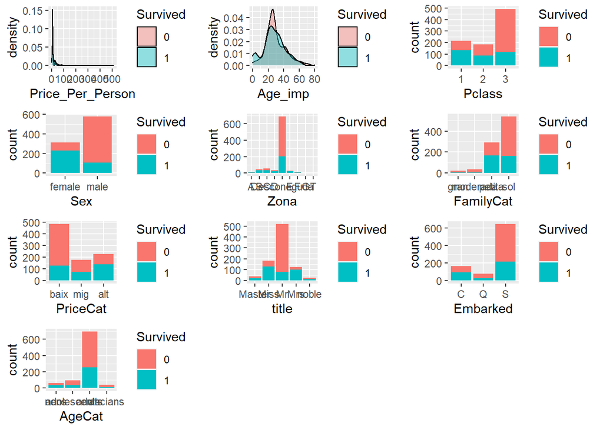

```r
# Variables continues
p_price<-ggplot(dataset_final[which(!(is.na(dataset_final$Survived))),], aes(x=Price_Per_Person, fill=Survived)) +
  geom_density(alpha=0.4)
p_age<-ggplot(dataset_final[which(!(is.na(dataset_final$Survived))),], aes(x=Age_imp, fill=Survived)) +
  geom_density(alpha=0.4)

# Variables categoriques
p_class<-ggplot(dataset_final[which(!(is.na(dataset_final$Survived))),])+geom_bar(aes(x=Pclass, fill=Survived))
p_sex<-ggplot(dataset_final[which(!(is.na(dataset_final$Survived))),])+geom_bar(aes(x=Sex, fill=Survived))
p_zona<-ggplot(dataset_final[which(!(is.na(dataset_final$Survived))),])+geom_bar(aes(x=Zona, fill=Survived))
p_familyCat<-ggplot(dataset_final[which(!(is.na(dataset_final$Survived))),])+geom_bar(aes(x=FamilyCat, fill=Survived))
p_priceCat<-ggplot(dataset_final[which(!(is.na(dataset_final$Survived))),])+geom_bar(aes(x=PriceCat, fill=Survived))
p_title<-ggplot(dataset_final[which(!(is.na(dataset_final$Survived))),])+geom_bar(aes(x=title, fill=Survived))
p_Embarked<-ggplot(dataset_final[which(!(is.na(dataset_final$Survived))),])+geom_bar(aes(x=Embarked, fill=Survived))
p_AgeCat<-ggplot(dataset_final[which(!(is.na(dataset_final$Survived))),])+geom_bar(aes(x=AgeCat, fill=Survived))

figure_Dis <- ggarrange(p_price,p_age,p_class,p_sex,p_zona,p_familyCat,p_priceCat,p_title,p_Embarked,p_AgeCat, ncol = 3, nrow = 4)

figure_Dis
```

## 4.4 Comparació entre dos grups de dades (variables continues)

Comprovem si hi ha diferencies significatives en la edat i el preu del bitllet entre la gent que va sobreviure i els que van morir.

```r
wilcox.test(Price_Per_Person ~ Survived, data = dataset_final[which(!(is.na(dataset_final$Survived))),])
```

```
##
##  Wilcoxon rank sum test with continuity correction
##
## data:  Price_Per_Person by Survived
## W = 64104, p-value = 1.551e-15
## alternative hypothesis: true location shift is not equal to 0
```

```r
wilcox.test(Age_imp ~ Survived, data = dataset_final[which(!(is.na(dataset_final$Survived))),])
```

```
##
##  Wilcoxon rank sum test with continuity correction
##
## data:  Age_imp by Survived
## W = 97870, p-value = 0.2849
## alternative hypothesis: true location shift is not equal to 0
```

## 4.5 Comparació entre dos grups de dades (variables categoriques)

Mirem si hi ha diferencies entre les proporcions dels diferents grups de les variables categoriques entre la gent que va sobreviure i la que va morir.

```r
# Segons el sexe
sup_sex<-t(table(dataset_final[which(!(is.na(dataset_final$Survived))),]$Sex,dataset_final[which(!(is.na(dataset_final$Survived))),]$Survived))
sup_sex
```

```
##
##     female male
##   0     81  468
##   1    233  109
```

```r
chisq.test(sup_sex)
```

```
##
##  Pearson's Chi-squared test with Yates' continuity correction
##
## data:  sup_sex
## X-squared = 260.72, df = 1, p-value < 2.2e-16
```

```r
# Segons la zona
sup_zona<-t(table(dataset_final[which(!(is.na(dataset_final$Survived))),]$Zona,dataset_final[which(!(is.na(dataset_final$Survived))),]$Survived))
sup_zona
```

```
##
##       A   B   C   D Desconeguda   E   F   G   T
##   0   8  12  24   8         481   8   5   2   1
##   1   7  35  35  25         206  24   8   2   0
```

```r
chisq.test(sup_zona)
```

```
##
##  Pearson's Chi-squared test
##
## data:  sup_zona
## X-squared = 99.164, df = 8, p-value < 2.2e-16
```

```r
# Segons el tamany de familia
sup_FamilyCat<-t(table(dataset_final[which(!(is.na(dataset_final$Survived))),]$FamilyCat,dataset_final[which(!(is.na(dataset_final$Survived))),]$Survived))
sup_FamilyCat
```

```
##
##     gran moderada petita sol
##   0   21       31    123 374
##   1    4        6    169 163
```

```r
chisq.test(sup_FamilyCat)
```

```
##
##  Pearson's Chi-squared test
##
## data:  sup_FamilyCat
## X-squared = 74.538, df = 3, p-value = 4.552e-16
```

```r
# Segons el tamany del preu del bitllet
sup_PriceCat<-t(table(dataset_final[which(!(is.na(dataset_final$Survived))),]$PriceCat,dataset_final[which(!(is.na(dataset_final$Survived))),]$Survived))
sup_PriceCat
```

```
##
##     baix mig alt
##   0  356 103  90
##   1  128  74 140
```

```r
chisq.test(sup_PriceCat)
```

```
##
##  Pearson's Chi-squared test
##
## data:  sup_PriceCat
## X-squared = 79.21, df = 2, p-value < 2.2e-16
```

```r
# Segons el titol que es tingui
sup_title<-t(table(dataset_final[which(!(is.na(dataset_final$Survived))),]$title,dataset_final[which(!(is.na(dataset_final$Survived))),]$Survived))
sup_title
```

```
##
##     Master Miss  Mr Mrs noble
##   0     17   55 436  26    15
##   1     23  127  81  99    12
```

```r
chisq.test(sup_title)
```

```
##
##  Pearson's Chi-squared test
##
## data:  sup_title
## X-squared = 283.31, df = 4, p-value < 2.2e-16
```

```r
# Segons on s'ha embarcat
sup_Embarked<-t(table(dataset_final[which(!(is.na(dataset_final$Survived))),]$Embarked,dataset_final[which(!(is.na(dataset_final$Survived))),]$Survived))
sup_Embarked
```

```
##
##       C   Q   S
##   0  75  47 427
##   1  93  30 219
```

```r
chisq.test(sup_Embarked)
```

```
##
##  Pearson's Chi-squared test
##
## data:  sup_Embarked
## X-squared = 25.964, df = 2, p-value = 2.301e-06
```

```r
# Segons la categoria d'edat
sup_AgeCat<-t(table(dataset_final[which(!(is.na(dataset_final$Survived))),]$AgeCat,dataset_final[which(!(is.na(dataset_final$Survived))),]$Survived))
sup_AgeCat
```

```
##
##     nens adolescents adults ancians
##   0   26          58    438      27
##   1   38          36    256      12
```

```r
chisq.test(sup_AgeCat)
```

```
##
##  Pearson's Chi-squared test
##
## data:  sup_AgeCat
## X-squared = 13.537, df = 3, p-value = 0.003608
```

Podem observar que hi ha diferencies significatives entre les diferents classes de totes les variables categoriques analitzades entre la gent que va sobreviure i la que va morir.

## 4.6 Correlació entre variables

Calculem la correlació entre les variables continues. Utilitzem el metode de “Spearman” ja que les dades no segueixen una distribució normal.

```r
dataset_final_cont<-dataset_final[,c("Price_Per_Person","Age_imp")]
cor.test(dataset_final_cont$Price_Per_Person,dataset_final_cont$Age_imp, method = "spearman")
```

```
##
##  Spearman's rank correlation rho
##
## data:  dataset_final_cont$Price_Per_Person and dataset_final_cont$Age_imp
## S = 215464945, p-value < 2.2e-16
## alternative hypothesis: true rho is not equal to 0
## sample estimates:
##       rho
## 0.4236196
```

Podem observar com l’edat és correlaciona significativament amb el preu del bitllet pagat.

```r
corr.res<-cor(dataset_final_cont, method = 'spearman')
# Si tinguessim més variables podriem crear un grafic amb el codi següent:
#corrplot.mixed(corr.res,upper="circle",number.cex=.7,tl.cex=.8)
```

# 5 Modelització

## 5.1 Arbre de decisió

**Construcció del model**

Una manera d’analitzar el dataset és aplicant un model de classificació basat en arbre, el qual ens permetrà veure quines variables tenen més influència a l’hora de determinar la probabilitat de supervivència de cada passatger a partir de les variables que el configuren.

Com que les dades estan ordenades i cal barrejar-les per tal que la tria sigui el màxim d’equitativa possible i no interfereixi amb el resultat que proporcionarà el model. Per fer-ho, apliquem el següent codi i guardem el resultat a la variable *dataset_train_random*:

```r
set.seed(1912)
dataset_train_random <- dataset_train[sample(nrow(dataset_train)),]
str(dataset_train_random)
```

```
## 'data.frame':    891 obs. of  12 variables:
##  $ PassengerId     : int  347 499 28 29 144 428 87 65 2 188 ...
##  $ Pclass          : Factor w/ 3 levels "1","2","3": 2 1 1 3 3 2 3 1 1 1 ...
##  $ Sex             : Factor w/ 2 levels "female","male": 1 1 2 1 2 1 2 2 1 2 ...
##  $ Zona            : Factor w/ 9 levels "A","B","C","D",..: 5 3 3 5 5 5 5 5 3 5 ...
##  $ FamilyCat       : Factor w/ 4 levels "gran","moderada",..: 4 3 2 4 4 4 2 4 3 4 ...
##  $ Price_Per_Person: num  13 37.89 43.83 7.88 6.75 ...
##  $ PriceCat        : Factor w/ 3 levels "baix","mig","alt": 2 3 3 1 1 3 1 3 3 3 ...
##  $ Age_imp         : num  40 25 19 22 19 19 16 42 38 45 ...
##  $ title           : Factor w/ 5 levels "Master","Miss",..: 2 4 3 2 3 2 3 3 4 3 ...
##  $ Embarked        : Factor w/ 3 levels "C","Q","S": 3 3 3 2 2 3 3 1 1 3 ...
##  $ AgeCat          : Factor w/ 4 levels "nens","adolescents",..: 3 3 3 3 3 3 2 3 3 3 ...
##  $ Survived        : Factor w/ 2 levels "0","1": 2 1 1 2 1 2 1 1 2 2 ...
```

```r
set.seed(1912)
y <- dataset_train_random[,"Survived"]
x <- dataset_train_random[,c("Pclass","Sex","FamilyCat","PriceCat","title","Embarked","AgeCat")]
```

Un cop obtinguda la mostra desordenada, anem a dividir el conjunt d edades en mostres d’entrenament i test. El conjunt d’entrenament serà aquell que s’utilitzarà per construir el model i el conjunt de proves el que s’utilitzarà per avaluar la seva precisió. Seguidament obtenim els diferents conjunts d’entrenament i test a partir de la proporció de casos que hem triat per cada conjunt (2/3 i 1/3) utilitzant la funció *sample*:

```r
set.seed(1912)
indexes = sample(1:nrow(x), size=floor((2/3)*nrow(x)))
train_x <- x[indexes,]
train_y <- y[indexes]
test_x  <- x[-indexes,]
test_y  <- y[-indexes]
```

Per poder executar el mètode cal que no existeixin valors nul, els eliminem. Per això hem creat una funció que retorna els indexs de les files que contenen algun valor nul en un dataframe.

```r
indices_with_na <- function(data) {
  iwn <- c()
  for (i in c(1:nrow(data))) {
    if (any(is.na(data[i,]))) {
      iwn <- c(iwn, i)
    }
  }
  return(iwn)
}
```

Comprovem utilitzant la funció has_na que no hi ha variables del dataset amb valors nul:

```r
has_na(train_x)
```

```
## [1] "No hi ha cap variable amb valors nul"
```

```r
has_na(test_x)
```

```
## [1] "No hi ha cap variable amb valors nul"
```

I que tant les variables descriptives com les corresponents a la classe tenen la mateixa mida:

```r
nrow(train_x) == length(train_y)
```

```
## [1] TRUE
```

```r
nrow(test_x) == length(test_y)
```

```
## [1] TRUE
```

Un cop preparades les variables que s’utilitzaran, creem el model utilitzant l’algoritme C5.0 de la llibreria C50 i observem un resum del model generat.

```r
model_tree <- C50::C5.0(train_x, train_y, rules=TRUE)
summary(model_tree)
```

```
##
## Call:
## C5.0.default(x = train_x, y = train_y, rules = TRUE)
##
##
## C5.0 [Release 2.07 GPL Edition]      Tue Jan 05 23:54:06 2021
## -------------------------------
##
## Class specified by attribute `outcome'
##
## Read 594 cases (8 attributes) from undefined.data
##
## Rules:
##
## Rule 1: (21, lift 1.6)
##  Pclass = 3
##  FamilyCat = moderada
##  ->  class 0  [0.957]
##
## Rule 2: (347/62, lift 1.4)
##  Sex = male
##  title in {Mr, noble}
##  ->  class 0  [0.819]
##
## Rule 3: (129/9, lift 2.2)
##  Pclass in {1, 2}
##  Sex = female
##  ->  class 1  [0.924]
##
## Rule 4: (205/42, lift 1.9)
##  Sex = female
##  FamilyCat in {gran, petita, sol}
##  ->  class 1  [0.792]
##
## Rule 5: (26/10, lift 1.5)
##  title = Master
##  ->  class 1  [0.607]
##
## Default class: 0
##
```

[output cut: 10 more lines]

```
##     (a)   (b)    <-classified as
##    ----  ----
##     304    44    (a): class 0
##      62   184    (b): class 1
##
##
##  Attribute usage:
##
##   93.77% Sex
##   62.79% title
##   38.05% FamilyCat
##   25.25% Pclass
##
##
## Time: 0.0 secs
```

Podem observar gràficament el model generat si el construïm sense mostrar les regles i el passem a la funció plot:

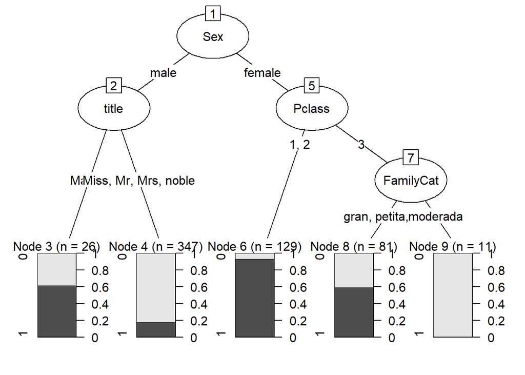

```r
model_tree_for_plot <- C50::C5.0(train_x, train_y)
plot(model_tree_for_plot)
```

**Avaluació del model**

Amb el model d’arbre de decisió creat a partir de les dades del conjunt d’entrenament podem avaluar la seva eficiència intentant predir les dades que es troben al conjunt de prova. Per fer-ho utilitzem la funció *predict* de R que classifica els diferents registres del conjunt de prova (test_X) utilitzant el model que rep (model_tree).

```r
predicted_test <- predict(model_tree,test_x, type="class")
```

Si observem el resultat d’aquesta funció veiem que es correspon a un vector amb les etiquetes de la classe. Per comprovar la precisió de l’arbre avaluem quantes d’aquestes etiquetes predites es corresponen al valor real que té el registre comparant-lo amb el contingut de la variable *test_y*:

```r
precisio_model <- sum(predicted_test == test_y)/length(predicted_test)
print(paste("La precisió del model és de ", round(precisio_model*100,2), "%", sep=""))
```

```
## [1] "La precisió del model és de 82.15%"
```

**Comentaris del model**

També hem pogut veure que la variable que té més pes a l’hora de determinar el destí dels passatgers del titanic és el sexe, el qual té un pes del 93.77% en el model creat. El títol nobiliari del passatger també guarda una forta relació amb el model, mantenint un 62.79%. Finalment trobem que la dimensió de la família i classe dels tiquets també tenen una influència considerable però menor respecte les dues anteriors comentades.

## 5.2 Support Vector Machine

**Construcció del model**

Per construir un model basat en SVM utilitzarem les mateixes dades transformades que en l’apartat anterior ja que al igual que els arbres de decisió, un model basat en svm utilitza també variables categòriques.

A l’hora de cridar la funció encarregada de crear el model cal que tan la classe com les variables descriptives es trobin en el mateix dataframe així que fusionem la classe i les variables descriptives i comprovem que s’han fusionat correctament:

```r
train_x["Fate"] <- train_y
str(train_x)
```

```
## 'data.frame':    594 obs. of  8 variables:
##  $ Pclass   : Factor w/ 3 levels "1","2","3": 3 3 3 3 3 1 3 1 1 2 ...
##  $ Sex      : Factor w/ 2 levels "female","male": 1 2 2 2 2 1 2 1 1 2 ...
##  $ FamilyCat: Factor w/ 4 levels "gran","moderada",..: 2 4 4 3 2 3 4 3 3 4 ...
##  $ PriceCat : Factor w/ 3 levels "baix","mig","alt": 1 1 2 1 1 2 1 3 3 2 ...
##  $ title    : Factor w/ 5 levels "Master","Miss",..: 4 3 3 3 1 4 3 4 4 3 ...
##  $ Embarked : Factor w/ 3 levels "C","Q","S": 3 3 3 3 3 3 3 3 3 3 ...
##  $ AgeCat   : Factor w/ 4 levels "nens","adolescents",..: 3 3 3 2 1 3 3 3 3 2 ...
##  $ Fate     : Factor w/ 2 levels "0","1": 1 2 1 1 1 2 1 2 1 1 ...
```

Seguidament ja podem crear el model, per la qual cosa és necessari especificar a priori la classe i les variables descriptives que intervenen en el procés. Per la creació del model basat en Support Vector Machine utilitzem la funció *svm* del paquet *E1071*.

```r
SVM_model.train <- svm(Fate ~ Pclass + Sex + Embarked + title + FamilyCat + AgeCat, data = train_x, probability = TRUE)
```

Un cop creat el model, n’observem un resum utilitzant la funció *summary*:

```r
summary(SVM_model.train)
```

```
##
## Call:
## svm(formula = Fate ~ Pclass + Sex + Embarked + title + FamilyCat +
##     AgeCat, data = train_x, probability = TRUE)
##
##
## Parameters:
##    SVM-Type:  C-classification
##  SVM-Kernel:  radial
##        cost:  1
##
## Number of Support Vectors:  290
##
##  ( 147 143 )
##
##
## Number of Classes:  2
##
## Levels:
##  0 1
```

**Avaluació del model**

Un cop creat el model procedim a avaluar-lo predint els casos de test. Per fer-ho, al igual que en l’apartat anterior fem ús de la funció *predict*, la qual rep el model creat i els registres dels casos que es volen predir.

```r
SVM_pred.test <- predict(SVM_model.train, test_x)
```

Una manera de visualitzar els resultats és utilitzant una matriu de confusió. La funció *CrossTable* de la llibreria *gmodels* ofereix una manera simple de presentar els resultats utilitzant una matriu de confusió però amb més detall:

```r
CrossTable(test_y, SVM_pred.test, prop.chisq = FALSE, prop.c = FALSE, prop.r = FALSE, dnn = c("Realitat", "Predicció"))
```

```
##
##
##    Cell Contents
## |-------------------------|
## |                       N |
## |         N / Table Total |
## |-------------------------|
##
##
## Total Observations in Table:  297
##
##
##              | Predicció
##     Realitat |         0 |         1 | Row Total |
## -------------|-----------|-----------|-----------|
##            0 |       176 |        25 |       201 |
##              |     0.593 |     0.084 |           |
## -------------|-----------|-----------|-----------|
##            1 |        25 |        71 |        96 |
##              |     0.084 |     0.239 |           |
## -------------|-----------|-----------|-----------|
## Column Total |       201 |        96 |       297 |
## -------------|-----------|-----------|-----------|
##
##
```

Per avaluar la precisió del model utilitzem una matriu de confusió simple com en l’apartat anterior:

```r
matriu_conf_svm <- table(test_y,Predicted=SVM_pred.test)
precisio_model_matriu_conf <- sum(diag(matriu_conf_svm)) / sum(matriu_conf_svm)
print(paste("La precisió del model és de ", round(precisio_model_matriu_conf*100,2), "%", sep=""))
```

```
## [1] "La precisió del model és de 83.16%"
```

**Comentaris del model**

Utilitzant el model basat en SVM obtenim una precisió del 83.16%, lleugerament millor que el que s’ha obtingut utilitzant arbres de decisió.

## 5.3 Regressió logística

**Construcció del model**

Un altre mètode per analitzar les dades és aplicant una regressió logística, ja que aquesta ens permet realitzar una classificació a partir de la descripció d’un registre. Per crear el model podem utilitzar la funció *glm*, on cal especificar la variable a predir (*Fate*), les variables descriptives i el dataframe que s’utilitza. També cal especificar que la classe que es vol predir consta de nomes dos valors establint el valor *binomial* al paràmetre *family*.

```r
model_glm <- glm(formula=Fate~Pclass+Sex+FamilyCat+PriceCat+title+Embarked+AgeCat,data=train_x,family=binomial(link=logit))
```

Un cop creat el model podem visualitzar-ne la seva descripció utilitzant la funció *summary*:

```r
summary(model_glm)
```

```
##
## Call:
## glm(formula = Fate ~ Pclass + Sex + FamilyCat + PriceCat + title +
##     Embarked + AgeCat, family = binomial(link = logit), data = train_x)
##
## Deviance Residuals:
##     Min       1Q   Median       3Q      Max
## -2.6227  -0.5517  -0.4105   0.6065   2.3356
##
## Coefficients:
##                   Estimate Std. Error z value Pr(>|z|)
## (Intercept)        17.0780   723.7232   0.024 0.981174
## Pclass2            -0.4093     0.5539  -0.739 0.459984
## Pclass3            -0.8393     0.5717  -1.468 0.142080
## Sexmale           -15.8492   723.7226  -0.022 0.982528
## FamilyCatmoderada  -1.1502     0.8344  -1.379 0.168040
## FamilyCatpetita     1.6594     0.6940   2.391 0.016806 *
## FamilyCatsol        1.8880     0.7162   2.636 0.008389 **
## PriceCatmig         0.2328     0.4413   0.528 0.597824
## PriceCatalt         1.2238     0.5390   2.270 0.023186 *
## titleMiss         -16.4153   723.7229  -0.023 0.981904
## titleMr            -3.7152     0.7746  -4.796 1.62e-06 ***
## titleMrs          -15.9900   723.7230  -0.022 0.982373
## titlenoble         -3.9943     1.0658  -3.748 0.000179 ***
## EmbarkedQ          -0.6260     0.5041  -1.242 0.214316
## EmbarkedS          -0.4867     0.3104  -1.568 0.116871
## AgeCatadolescents  -0.5405     0.6420  -0.842 0.399858
## AgeCatadults       -0.3678     0.6461  -0.569 0.569195
## AgeCatancians      -1.8602     0.8827  -2.107 0.035075 *
## ---
## Signif. codes:  0 '***' 0.001 '**' 0.01 '*' 0.05 '.' 0.1 ' ' 1
##
## (Dispersion parameter for binomial family taken to be 1)
##
##     Null deviance: 805.86  on 593  degrees of freedom
## Residual deviance: 493.45  on 576  degrees of freedom
## AIC: 529.45
##
## Number of Fisher Scoring iterations: 14
```

**Avaluació del model**

Per avaluar el model tornem a utilitzar els registres de la variable *test_x* i els passem a la funció *predict*:

```r
probs_prediction_glm <- predict(model_glm, newdata=test_x, type="response")
head(probs_prediction_glm)
```

```
##         28        251        157        217         16        360
## 0.03671277 0.09177948 0.63297456 0.70201595 0.87491594 0.67209419
```

Com podem veure la predicció d’aquest model retorna la probabilitat de que els registre pertanyin o no a la variable dictòmica que es vol predir, motiu pel qual cal realitzar una conversió als valors 0 i 1 abans de poder comparar els resultats predits amb els reals de la variable test_y:

```r
prediction_glm <- c()
for (i in probs_prediction_glm) {
  if (i<0.5)
    prediction_glm <- c(prediction_glm,0)
  else
    prediction_glm <- c(prediction_glm,1)
}
```

Un cop obtinguts els valors predits amb el mateix format dels valors reals, procedim a crear una matriu de confusió per veure com s’han distribuït els encerts i les errades:

```r
CrossTable(test_y, prediction_glm, prop.chisq = FALSE, prop.c = FALSE, prop.r = FALSE, dnn = c("Realitat", "Predicció"))
```

```
##
##
##    Cell Contents
## |-------------------------|
## |                       N |
## |         N / Table Total |
## |-------------------------|
##
##
## Total Observations in Table:  297
##
##
##              | Predicció
##     Realitat |         0 |         1 | Row Total |
## -------------|-----------|-----------|-----------|
##            0 |       174 |        27 |       201 |
##              |     0.586 |     0.091 |           |
## -------------|-----------|-----------|-----------|
##            1 |        21 |        75 |        96 |
##              |     0.071 |     0.253 |           |
## -------------|-----------|-----------|-----------|
## Column Total |       195 |       102 |       297 |
## -------------|-----------|-----------|-----------|
##
##
```

Per obtenir una mesura de la bondat del model apliquem el mateix procediment que el que hem vist en els dos subapartats anteriors, fent ús de la matriu de confusió:

```r
matriu_conf_glm <- table(test_y,Predicted=prediction_glm)
precisio_model_matriu_conf_glm <- sum(diag(matriu_conf_glm)) / sum(matriu_conf_glm)
print(paste("La precisió del model és de ", round(precisio_model_matriu_conf_glm*100,2), "%", sep=""))
```

```
## [1] "La precisió del model és de 83.84%"
```

**Comentaris del model**

Utilitzant la regressió logística obtenim una precisió del 83.84%, lleugerament superior a la resta de modelitzacions provades. Observant el resum del model podem veure com les categòries que més influèixen en la decisió de la classe d’un passatger utilitzant aquesta modelització és quan el títol del passatger és noble o simplement Mr (ja que indica que no poseeix cap títol nobiliari i pertany al gènere masculí). També influeix que el passatger viatgi sol o amb poca companyia i el fet de si és o no ancià.

# 6 Predicció

Arribats a aquest punt hem volgut presentar-hi els nostres resultats a la competició activa de la pàgina Kaggle. Per fer-ho hem predit els registres corresponents al fitxer de test (*test.csv*) utilitzant el model que ens ha donat millors resultats: el model basat en la regressió logística.

```r
# Obtenim les probabilitats de classe dels registes corresponents a l'apartat de test
probs_prediction_glm_competition <- predict(model_glm, newdata=dataset_test, type="response")
# Convertim les probabilitats en predicció
prediction_glm_comp <- c()
for (i in probs_prediction_glm_competition) {
  if (i<0.5)
    prediction_glm_comp <- c(prediction_glm_comp,0)
  else
    prediction_glm_comp <- c(prediction_glm_comp,1)
}
```

Un cop obtinguda la predicció la guardem en un dataframe amb l’identificador del passatger:

```r
df_competition <- data.frame(dataset_test$PassengerId,prediction_glm_comp)
colnames(df_competition) <- c("PassengerId", "Survived")
```

Finalment generem el fitxer csv que conté la predicció:

```r
write.csv(df_competition, "out/prediction_comp.csv", row.names=FALSE, quote=FALSE)
```

# 7 Resum

# 8 Conclusions

Com ja s’ha pogut veure al llarg d’aquest informe, hem utilitzat moltes tècniques diferents per tal d’aconseguir netejar, preprocessar i analitzar les dades del dataset escollit. Entre altres coses hem consolidat conceptes relatius al tractament de valors nuls i extrems, discretització de variables, aplicació de testos per avaluar la normalitat i homoscedasticitat d’una variable, aplicació de testos per a testejar hipotesis, generació i avaluació de models predictius, generació de gràfics d’interés, etc.

També ens agradaria comentar que una de les coses que ens ha cridat més l’atenció ha estat veure com la creació d’una variable particular (title) ha aportat als models predictius creats tanta informació i ens ha recordat com el preprocessat és de les etapes més importants a l’hora d’estudiar les dades. Al llarg d’aquesta pràctica hem consolidat diversos conceptes vistos al llarg de l’assignatura i hem après noves tècniques d’anàlisi i exploració de les dades, motiu pel qual considerem que ha estat molt productiva.

Tots els membres han contribuït de manera igualitaria en l’elaboració de la pràctica.

|  | Contribucions | Signa |
| --- | --- | --- |
|  | Investigació prèvia | AAS & ATP |
|  | Redacció de les respostes | AAS & ATP |
|  | Desenvolupament codi | AAS & ATP |

# 9 Bibliografia

- Calvo, M., Pérez, D., Subirats, L. (2019). Introducció a la neteja i anàlisi de les dades. Editorial UOC.
- Gil, A. J. (2019). Estadística descriptiva. Editorial UOC.
- Bernadó, E. (2020). Test d’hipòtesis. Editorial UOC.
- Rovira, C. (2019). Contrast d’hipòtesis. Editorial UOC.
- Gibergans, J. (2019). Contrast de variàncies. Editorial UOC.
- Sangüesa, R. (2019). Classificació: arbres de decisió. Editorial UOC.
- Guillén, M., Alonso, M. T. (2019). Models de regressió logística. Editorial UOC.
- Sangüesa, R. (2019). Avaluació de models. Editorial UOC.